# Pipeline analysis of *C. trachomatis* MAP data - October 2020

```r
library(tidyverse)
library(here)
library(zoo)
library(vroom)
source(here("MAP_functions.R"))
```

**“regular”** is a statistic I developed after seeing that the Ref_cov+alternate bases did not always quite equal the total coverage. In most cases, regular = 0, which means that the coverages do add up. There are a few bases +1 or -1. Fewer still have greater deviaiotn but a few positions have huge deviation +/1 3000nt which probably is an indication of weird mapping problems.

**pot_true_minors** means that coverage is at least 10, “regular” is -1,0 or 1 and there are alternate SNPs that fall between 0.1 and 0.9 allele frequency (this is what *SNP_percent* means).

**pot_true_SNP** means that coverage is at least 10, “regular” is -1,0 or 1 and there are alternate SNPs that fall below 0.1 and 0.9 allele frequency (ie dominated by the alternative, nonAST allele).

**cov10** means number of bases with 10 or above coverage

**map_value1** means “map_value” (Sandeep’s statistic meaning percent of the highest coverage) is 1 or less. All bases *should* be 1 or less but a few have weirdness.

```r
out_dir <- "~/Documents/2021-Fiji-Ct_paper/MAP_results/MAP_files/MAP_processing_results/"
```

# NOTE - FOR SOME REASON 107C NOT INCLUDED IN THIS Loop

```r
for (i in seq_along(MAP_files)){
loop_file <- MAP_files[i]
f_name <- sub("/","",str_extract(loop_file,"/.{2,4}[CRV]"))
MAP <- read_MAP(loop_file,f_name)
MAP_stats <- MAP_stats_summary(MAP,out_dir,f_name)
#plot_MAP_histo(MAP,out_dir,f_name)
#plot_MAP_coverage(MAP,out_dir,f_name)
write_potential_minors(MAP,out_dir,f_name)
write_potential_SNPs(MAP,out_dir,f_name)
}
```

## Create summary table

```r
MAP_summaries <- list.files(out_dir,full.names = T,pattern = "*_stats.tsv")
```

```r
MAP_summary_df <- read_tsv(MAP_summaries[1])
for (j in 2:length(MAP_summaries)) {
  temp_df <- read_tsv(MAP_summaries[j])
  MAP_summary_df <- bind_rows(MAP_summary_df,temp_df)
}
write_tsv(MAP_summary_df,here("MAP_analysis_summary2.tsv"))
```

### Take a look at high quality data

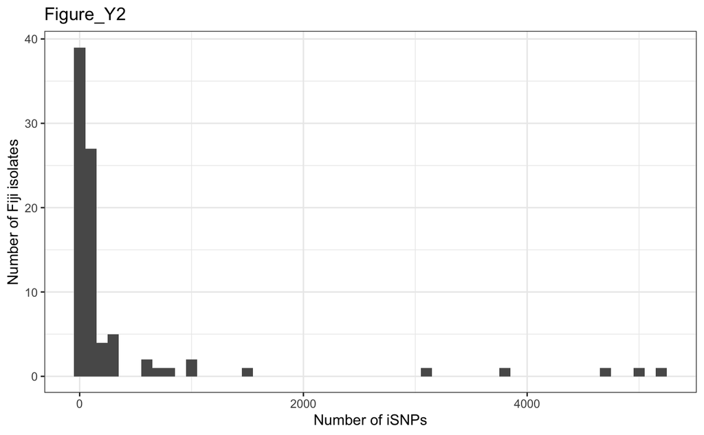

```r
MAP_summary_df %>%
  ggplot(aes(pot_true_minors)) +
  geom_histogram(binwidth=100) +
    xlab("Number of iSNPs") +
    ylab("Number of Fiji isolates") +
    ggtitle("Figure_Y2") +
    theme_bw()
```

## Isolates with high numbers of SNPs

```r
MAP_summary_df %>%
  filter(pot_true_minors > 1000)
```

| strain | total_nt | reg0 | map_value1 | reg_more_than_1 | map_value_more_than1 | cov10 | pot_true_minors | pot_true_SNP |
| --- | --- | --- | --- | --- | --- | --- | --- | --- |
| 1078V | 1041661 | 1040966 | 1004465 | 401 | 25 | 1016518 | 3771 | 313 |
| 1079R | 1041695 | 1040248 | 1021986 | 759 | 71 | 1019534 | 3108 | 2351 |
| 1176R | 1041934 | 1040515 | 1010893 | 661 | 83 | 1039496 | 1458 | 4380 |
| 1176V | 1042398 | 1041507 | 1024225 | 453 | 48 | 1027853 | 5159 | 523 |
| 1182R | 1042012 | 1041053 | 1020778 | 471 | 25 | 1036939 | 4719 | 278 |
| 32V | 1042149 | 1038301 | 988005 | 1688 | 73 | 1040321 | 4969 | 814 |

## Isolates with intermediate numbers of SNPs

```r
MAP_summary_df %>%
  filter(pot_true_minors > 500 & pot_true_minors < 1000)
```

| strain | total_nt | reg0 | map_value1 | reg_more_than_1 | map_value_more_than1 | cov10 | pot_true_minors | pot_true_SNP |
| --- | --- | --- | --- | --- | --- | --- | --- | --- |
| 1077R | 1040377 | 1039410 | 1027658 | 500 | 66 | 799453 | 741 | 3324 |
| 1078R | 1032527 | 1031569 | 1012170 | 619 | 73 | 875776 | 977 | 3511 |
| 1079V | 1041955 | 1040509 | 1015294 | 657 | 81 | 1036870 | 645 | 4771 |
| 1176C | 1041630 | 1040372 | 1018318 | 572 | 82 | 1036982 | 822 | 4883 |
| 1182V | 1042243 | 1036998 | 936821 | 1949 | 116 | 1040468 | 983 | 4534 |
| 968R | 1040096 | 1039479 | 1031809 | 291 | 37 | 578878 | 638 | 599 |

## Aggregate minor alleles

```r
MAP_minor_allele_files <- list.files(out_dir,full.names = T,pattern = "*_minors.tsv")
```

```r
MAP_minor_allele_df <- read_tsv(MAP_minor_allele_files[1],col_types=(cols(
  strain = col_character(),
  Position = col_integer(),
  Refnt = col_character(),
  Coverage = col_integer(),
  Ref_cov = col_integer(),
  Aa = col_integer(),
  Gg = col_integer(),
  Cc = col_integer(),
  Tt = col_integer())
))
for (j in 2:length(MAP_minor_allele_files)) {
  temp_df2 <- read_tsv(MAP_minor_allele_files[j],col_types=(cols(
  strain = col_character(),
  Position = col_integer(),
  Refnt = col_character(),
  Coverage = col_integer(),
  Ref_cov = col_integer(),
  Aa = col_integer(),
  Gg = col_integer(),
  Cc = col_integer(),
  Tt = col_integer())
))
  MAP_minor_allele_df <- bind_rows(MAP_minor_allele_df,temp_df2)
}
write_tsv(MAP_minor_allele_df,here("MAP_minor_alleles_df2.tsv"))
```